# HOMEWORK 4 DATA 1

Deniz Turhan

18 Aralık 2018

# **Data 1**

The first dataset I have chosen is about students’ performance of a high school.This is the [link](https://archive.ics.uci.edu/ml/datasets/student+performance) of which. There are 32 features including sex, age, address, family size, studytime, etc. There were many categorical variables beside the numerical ones. I converted the character ones to factors. Since there is only one data file, I splitted it as train and test data with the ratio 70%-30%.Then different models are used to build a regression for predicting final grade of the students.By doing this, some parameters are tuned to choose the best one for each model.Since tuning functions does cross validation, I could directly find train and test errors after I built model. It can be done by cross validation in a loop as well. I will also add that version in the Appendix.

```r
set.seed(123)

setwd('C:/Users/casper/Downloads')
dataraw<-data.frame(fread('student-mat.csv'))
dataraw<-dataraw %>% mutate(
        schoolsup = ifelse(schoolsup == "yes", 1, 0),
        famsup = ifelse(famsup == "yes", 1 , 0),
        paid = ifelse(paid == "yes", 1 , 0),
        activities = ifelse(activities == "yes", 1 , 0),
        nursery = ifelse(nursery == "yes", 1 , 0),
        higher = ifelse(higher == "yes", 1 , 0),
        internet = ifelse(internet == "yes", 1 , 0),
        romantic = ifelse(romantic == "yes", 1 , 0),
        sex = ifelse(sex == "F", 1 , 0),
        address = ifelse(address == "U", 1 , 0),
        famsize = ifelse(famsize == "GT3", 1 , 0),
        Pstatus = ifelse(Pstatus == "A", 1 , 0))
dataraw$Mjob = factor(dataraw$Mjob,levels = c( "at_home","health","other","services","teacher" ),labels = c(1, 2, 3,4,5))
dataraw$Fjob = factor(dataraw$Fjob,levels = c( "at_home","health","other","services","teacher" ),labels = c(1, 2, 3,4,5))
dataraw$reason = factor(dataraw$reason,levels = c( "course","other","home","reputation"),labels = c(1, 2, 3,4))
dataraw$guardian = factor(dataraw$guardian,levels = c( "mother", "father", "other"),labels = c(1, 2, 3))
dataraw<-as.data.table(dataraw)
dataraw[,G1:=as.numeric(G1)]
dataraw[,G2:=as.numeric(G2)]

smp_size <- floor(0.70 * nrow(dataraw))
train_ind <- sample(seq_len(nrow(dataraw)), size = smp_size)
train <- dataraw[train_ind, ]
test <- dataraw[-train_ind, ]

train=train[,2:ncol(train)]
trainG3=train[,G3]
test=test[,2:ncol(test)]
```

After data preprocessing, the parameters are tuned for all the models namely decision tree, support vector machine, random forest, and gradient boosting machine. As the performance metric, R-squared is used. R-squared values of all models are kept in a table for each model. The best model is chosen after parameter tuning and its R-squared is kept in the table. For penalized regression, glmnet function is used to try different lambda levels but it does not work correctly, so I will add that part in the Appendix. In decision tree, different levels of minimal number of observations per tree leaf and complexity parameter are tried by using “tune.rpart” function. In support vector machine, I tried different levels for penalty (cost) parameter. Additionally, I tried different degree parameters for polynomial kernel and different gamma parameters for gaussian kernel. The parameter m is tuned by function “tuneRF” for random forest model. Lastly, for the gradient boosting model, different levels of depth, learning rate and number of trees are tried by creating a grid and then train function.

```r
 #decision tree
     tunedt <- tune.rpart(G3~., data = train, minsplit = c(5,10,15), cp=c(0.01:0.1))
     rpartmodel=rpart(G3~.,data=train, method = "anova", control=rpart.control(minsplit=tunedt$best.parameters[1],cp=tunedt$best.parameters[2]))

     rparttrain=predict(rpartmodel,train)
     rss <- sum((rparttrain - train[,G3]) ^ 2)  ## residual sum of squares
     tss <- sum((train[,G3] - mean(train[,G3])) ^ 2)  ## total sum of squares
     rsqtr <- 1 - rss/tss
     print(paste("R_squared_train:",rsqtr))
```

```
## [1] "R_squared_train: 0.907821415717454"
```

```r
     rpartpredict=predict(rpartmodel,test)


     rss <- sum((rpartpredict - test[,G3]) ^ 2)  ## residual sum of squares
     tss <- sum((test[,G3] - mean(test[,G3])) ^ 2)  ## total sum of squares
     rsq <- 1 - rss/tss
     print(paste("R_squared:",rsq))
```

```
## [1] "R_squared: 0.881764957639404"
```

```r
     #aggregation of results, if it is first iteration, initialize the data table

       overallresults=data.table(Rep=1,Method="rpart",Rsquared=rsq)
```

In decision tree model, R-squared can be check for training error. In other words training error goes parallel by 1-0.9078=0.0922 whereas test error is parallel with 1-0.8818=0.1182 where 0.8818 is R-squared of prediction on test data.The best complexity parameter is 0.01 and min. number of observations per tree leaf is 15 for this model.

```r
 #Support Vector Machine
     tuning <- tune(svm, G3~., data = train,
                    ranges = list(gamma = 2^(-1:1), cost = 2^(2:4)),
                    tunecontrol = tune.control(sampling = "fix")
     )
     svmtrain<-predict(tuning$best.model, train)
     rss <- sum((svmtrain - train[,G3]) ^ 2)  ## residual sum of squares
     tss <- sum((train[,G3] - mean(train[,G3])) ^ 2)  ## total sum of squares
     rsq <- 1 - rss/tss
     print(paste("R_squared_train:",rsq))
```

```
## [1] "R_squared_train: 0.990907021938251"
```

```r
     svmmodel1deg7 <- svm(G3~., data=train,degree=7, kernel="polynomial",gamma=tuning$best.parameters[1], cost=tuning$best.parameters[2], type="eps-regression")

     svmpredict2deg7=predict(svmmodel1deg7, train)
     rss <- sum((svmpredict2deg7 - train[,G3]) ^ 2)  ## residual sum of squares
     tss <- sum((train[,G3] - mean(train[,G3])) ^ 2)  ## total sum of squares
     rsq1 <- 1 - rss/tss
     print(paste("R_squared1:",rsq1))
```

```
## [1] "R_squared1: 0.990534411892695"
```

```r
     svmmodel1deg3 <- svm(G3~., data=train,degree=3, kernel="polynomial",gamma=tuning$best.parameters[1], cost=tuning$best.parameters[2], type="eps-regression")

     svmpredict2deg3=predict(svmmodel1deg3, train)
     rss <- sum((svmpredict2deg3 - train[,G3]) ^ 2)  ## residual sum of squares
     tss <- sum((train[,G3] - mean(train[,G3])) ^ 2)  ## total sum of squares
     rsq2 <- 1 - rss/tss
     print(paste("R_squared2:",rsq2))
```

```
## [1] "R_squared2: 0.991559579304749"
```

```r
     svmmodel1deg5 <- svm(G3~., data=train,degree=5, kernel="polynomial",gamma=tuning$best.parameters[1], cost=tuning$best.parameters[2], type="eps-regression")

     svmpredict2deg5=predict(svmmodel1deg5, train)
     rss <- sum((svmpredict2deg5 - train[,G3]) ^ 2)  ## residual sum of squares
     tss <- sum((train[,G3] - mean(train[,G3])) ^ 2)  ## total sum of squares
     rsq3 <- 1 - rss/tss
     print(paste("R_squared3:",rsq3))
```

```
## [1] "R_squared3: 0.990844296817412"
```

```r
     rsqtr=max(rsq1, rsq2, rsq3)
     print(paste("R_squared_train:",rsqtr))
```

```
## [1] "R_squared_train: 0.991559579304749"
```

```r
     tuning$best.parameters #best parameters
```

```
##   gamma cost
## 1   0.5    4
```

```r
     svmpredicttest<-predict(svmmodel1deg3,test)
     rss <- sum((svmpredicttest - test[,G3]) ^ 2)  ## residual sum of squares
     tss <- sum((test[,G3] - mean(test[,G3])) ^ 2)  ## total sum of squares
     rsq <- 1 - rss/tss
     print(paste("R_squared2:",rsq)) #this is test R-square
```

```
## [1] "R_squared2: 0.561770305006354"
```

```r
     temp=data.table(Rep=1,Method="svm2",Rsquared=rsq)
     overallresults=rbind(overallresults,temp)
```

In support vector machine, two types of kernels are tried: Polynomial and Gaussian. In polynomial one, degree and cost parameters are tuned whereas in Gaussian, gamma and cost parameters are tuned.The best parameters are degree=3, gamma=0.5, and cost=4 are chosen with polynomial kernel. Train errors are relatively smaller than test error in SVM which shows that the model overfits the train data.

```r
#random forest
   train_nores<-train[,1:31]
   rf_tune<-tuneRF(train_nores, train[,G3], doBest = TRUE)
```

```
## mtry = 10  OOB error = 4.085799
## Searching left ...
## mtry = 5     OOB error = 5.934783
## -0.4525391 0.05
## Searching right ...
## mtry = 20    OOB error = 3.089961
## 0.2437315 0.05
## mtry = 31    OOB error = 3.032224
## 0.01868531 0.05
```

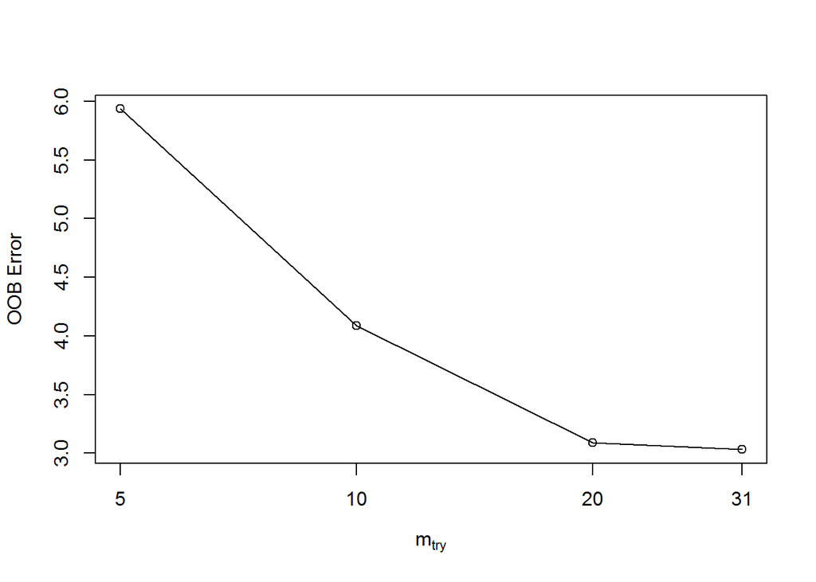

```r
   rfmodel<-randomForest(G3~., data = train, na.action=na.exclude, ntree=500, nodesize=5 , mtry=rf_tune$mtry)
 rfpredicttrain<-predict(rfmodel, train)
 rss <- sum((rfpredicttrain - train[,G3]) ^ 2)  ## residual sum of squares
 tss <- sum((train[,G3] - mean(train[,G3])) ^ 2)  ## total sum of squares
 rsqtr <- 1 - rss/tss
 print(paste("R_squared_train:",rsqtr))
```

```
## [1] "R_squared_train: 0.973411574450129"
```

```r
 rfpredict<-predict(rfmodel, test)
 rss <- sum((rfpredict - test[,G3]) ^ 2)  ## residual sum of squares
 tss <- sum((test[,G3] - mean(test[,G3])) ^ 2)  ## total sum of squares
 rsq <- 1 - rss/tss
 print(paste("R_squared:",rsq))
```

```
## [1] "R_squared: 0.901854326390796"
```

```r
 temp=data.table(Rep=1,Method="rf",Rsquared=rsq)
 overallresults=rbind(overallresults,temp)
```

Different m values are tried with tuneRF function for random forest model. At the end, m=31 is chosen and train R-square is 0.97 whereas test R-square is 0.90.

```r
 #gradient boosting


  gbmGrid <-  expand.grid(interaction.depth = c(1, 5, 9),
                          n.trees = c(300,500,700),
                          shrinkage =c(0.1,0.3,0.5,0.7) ,
                          n.minobsinnode = 10)

  gbmFit <- train(G3 ~ ., data = train,
                   method = "gbm",
                   verbose = FALSE,
                   tuneGrid = gbmGrid)

  gbmpredicttrain<-predict(gbmFit, train)

  rss <- sum((gbmpredicttrain - train[,G3]) ^ 2)  ## residual sum of squares
  tss <- sum((train[,G3] - mean(train[,G3])) ^ 2)  ## total sum of squares
  rsqtr <- 1 - rss/tss
  print(paste("R_squared_train:",rsqtr))
```

```
## [1] "R_squared_train: 0.996665079206863"
```

```r
  gbmFit$bestTune
```

```
##   n.trees interaction.depth shrinkage n.minobsinnode
## 7     300                 9       0.1             10
```

```r
  gbmpredict<-predict(gbmFit, test)


  rss <- sum((gbmpredict - test[,G3]) ^ 2)  ## residual sum of squares
  tss <- sum((test[,G3] - mean(test[,G3])) ^ 2)  ## total sum of squares
  rsq <- 1 - rss/tss
  print(paste("R_squared:",rsq))
```

```
## [1] "R_squared: 0.876755065036448"
```

```r
  temp=data.table(Rep=1,Method="gbm",Rsquared=rsq)
  overallresults=rbind(overallresults,temp)
```

```r
#to wide format

wideTableResults=dcast(overallresults, Rep~Method, value.var = "Rsquared")
wideTableResults
```

```
##    Rep       gbm        rf    rpart      svm2
## 1:   1 0.8767551 0.9018543 0.881765 0.5617703
```

All R-square values can be seen in the table above. SVM performed the worst for this data and random forest showed the best performance compared to other models.

# **Appendix**

Firstly I attached the code with cross validation below.

```r
set.seed(123)

setwd('C:/Users/casper/Downloads')
dataraw<-data.frame(fread('student-mat.csv'))
dataraw<-dataraw %>% mutate(
        schoolsup = ifelse(schoolsup == "yes", 1, 0),
        famsup = ifelse(famsup == "yes", 1 , 0),
        paid = ifelse(paid == "yes", 1 , 0),
        activities = ifelse(activities == "yes", 1 , 0),
        nursery = ifelse(nursery == "yes", 1 , 0),
        higher = ifelse(higher == "yes", 1 , 0),
        internet = ifelse(internet == "yes", 1 , 0),
        romantic = ifelse(romantic == "yes", 1 , 0),
        sex = ifelse(sex == "F", 1 , 0),
        address = ifelse(address == "U", 1 , 0),
        famsize = ifelse(famsize == "GT3", 1 , 0),
        Pstatus = ifelse(Pstatus == "A", 1 , 0))
dataraw$Mjob = factor(dataraw$Mjob,levels = c( "at_home","health","other","services","teacher" ),labels = c(1, 2, 3,4,5))
dataraw$Fjob = factor(dataraw$Fjob,levels = c( "at_home","health","other","services","teacher" ),labels = c(1, 2, 3,4,5))
dataraw$reason = factor(dataraw$reason,levels = c( "course","other","home","reputation"),labels = c(1, 2, 3,4))
dataraw$guardian = factor(dataraw$guardian,levels = c( "mother", "father", "other"),labels = c(1, 2, 3))
dataraw<-as.data.table(dataraw)
dataraw[,G1:=as.numeric(G1)]
dataraw[,G2:=as.numeric(G2)]

smp_size <- floor(0.70 * nrow(dataraw))
train_ind <- sample(seq_len(nrow(dataraw)), size = smp_size)
train <- dataraw[train_ind, ]
test <- dataraw[-train_ind, ]

train=train[,2:ncol(train)]
trainG3=train[,G3]
test=test[,2:ncol(test)]
cvindices=generateCVRuns(trainG3,ntimes=nofreplication,nfold=noffold,stratified=T)
firstIter=TRUE
nofreplication=1
noffold=5

for(i in 1:nofreplication){
  for(j in 1:noffold) {
    testindices=cvindices[[i]][[j]]
    cvtrain=train[-testindices,]
    cvtest=train[testindices,]
    cvtrain<-unique(cvtrain)
    cvtest<-unique(cvtest)


    #penalized regression
    CVG3<-cvtrain$G3
    cvtrain2<-copy(cvtrain)
    cvtrain2<-as.data.table(cvtrain2)
    cvtrain2[, names(cvtrain2) := lapply(.SD, as.numeric)]
    cvtrain2<-as.matrix(cvtrain2)

    lassopen<-glmnet(cvtrain2, CVG3, family = "gaussian", alpha = 1, nlambda = 20 )



    cvtest2<-copy(cvtest)
    cvtest2<-as.data.table(cvtest2)
    cvtest2[, names(cvtest2) := lapply(.SD, as.numeric)]
    cvtest2<-as.matrix(cvtest2)

    lassopredict<-predict(lassopen, cvtest2)

    rss <- sum((lassopredict - cvtest[,G3]) ^ 2)  ## residual sum of squares
    tss <- sum((cvtest[,G3] - mean(cvtest[,G3])) ^ 2)  ## total sum of squares
    rsq <- 1 - rss/tss
    print(paste("R_squared:",rsq))

    #aggregation of results, if it is first iteration, initialize the data table
    if(firstIter){
      overallresults=data.table(Rep=i,Fold=j,Method="penalized",Rsquared=rsq)
      firstIter=FALSE
    } else {
      temp=data.table(Rep=i,Fold=j,Method="penalized",Rsquared=rsq)
      overallresults=rbind(overallresults,temp)
    }


    #decision tree
    tunedt <- tune.rpart(G3~., data = cvtrain, minsplit = c(5,10,15), cp=c(0.01:0.1))
    rpartmodel=rpart(G3~.,data=cvtrain, method = "anova", control=rpart.control(minsplit=tunedt$best.parameters[1],cp=tunedt$best.parameters[2]))
    rpartpredict=predict(rpartmodel,cvtest)


    rss <- sum((rpartpredict - cvtest[,G3]) ^ 2)  ## residual sum of squares
    tss <- sum((cvtest[,G3] - mean(cvtest[,G3])) ^ 2)  ## total sum of squares
    rsq <- 1 - rss/tss
    print(paste("R_squared:",rsq))
    temp=data.table(Rep=i,Fold=j,Method="rpart",Rsquared=rsq)
    overallresults=rbind(overallresults,temp)


    #Support Vector Machine
    tuning <- tune(svm, G3~., data = cvtrain,
                   ranges = list(gamma = 2^(-1:1), cost = 2^(2:4)),
                   tunecontrol = tune.control(sampling = "fix")
    )
    svmpredict1=predict(tuning$best.model, cvtest)
    rss <- sum((svmpredict1 - cvtest[,G3]) ^ 2)  ## residual sum of squares
    tss <- sum((cvtest[,G3] - mean(cvtest[,G3])) ^ 2)  ## total sum of squares
    rsq <- 1 - rss/tss
    print(paste("R_squared:",rsq))
    temp=data.table(Rep=i,Fold=j,Method="svm1",Rsquared=rsq)
    overallresults=rbind(overallresults,temp)
    svmmodel1deg7 <- svm(G3~., data=cvtrain,degree=7, kernel="polynomial",gamma=tuning$best.parameters[1], cost=tuning$best.parameters[2], type="eps-regression")

    svmpredict2deg7=predict(svmmodel1deg7, cvtest)
    rss <- sum((svmpredict2deg7 - cvtest[,G3]) ^ 2)  ## residual sum of squares
    tss <- sum((cvtest[,G3] - mean(cvtest[,G3])) ^ 2)  ## total sum of squares
    rsq1 <- 1 - rss/tss
    print(paste("R_squared1:",rsq1))
    svmmodel1deg3 <- svm(G3~., data=cvtrain,degree=3, kernel="polynomial",gamma=tuning$best.parameters[1], cost=tuning$best.parameters[2], type="eps-regression")

    svmpredict2deg3=predict(svmmodel1deg3, cvtest)
    rss <- sum((svmpredict2deg3 - cvtest[,G3]) ^ 2)  ## residual sum of squares
    tss <- sum((cvtest[,G3] - mean(cvtest[,G3])) ^ 2)  ## total sum of squares
    rsq2 <- 1 - rss/tss
    print(paste("R_squared2:",rsq2))
    svmmodel1deg5 <- svm(G3~., data=cvtrain,degree=5, kernel="polynomial",gamma=tuning$best.parameters[1], cost=tuning$best.parameters[2], type="eps-regression")

    svmpredict2deg5=predict(svmmodel1deg5, cvtest)
    rss <- sum((svmpredict2deg5 - cvtest[,G3]) ^ 2)  ## residual sum of squares
    tss <- sum((cvtest[,G3] - mean(cvtest[,G3])) ^ 2)  ## total sum of squares
    rsq3 <- 1 - rss/tss
    print(paste("R_squared3:",rsq3))

    rsq=min(rsq1, rsq2, rsq3)
    print(paste("R_squared:",rsq))

    temp=data.table(Rep=i,Fold=j,Method="svm2",Rsquared=rsq)
    overallresults=rbind(overallresults,temp)




    #random forest
    cvtrain_nores<-cvtrain[,1:31]
    rf_tune<-tuneRF(cvtrain_nores, cvtrain[,G3], doBest = TRUE)

    rfmodel<-randomForest(G3~., data = cvtrain, na.action=na.exclude, ntree=500, nodesize=5 , mtry=rf_tune$mtry)
    rfpredict<-predict(rfmodel, cvtest)
    rss <- sum((rfpredict - cvtest[,G3]) ^ 2)  ## residual sum of squares
    tss <- sum((cvtest[,G3] - mean(cvtest[,G3])) ^ 2)  ## total sum of squares
    rsq <- 1 - rss/tss
    print(paste("R_squared:",rsq))
    temp=data.table(Rep=i,Fold=j,Method="rf",Rsquared=rsq)
    overallresults=rbind(overallresults,temp)

    #gradient boosting


    gbmGrid <-  expand.grid(interaction.depth = c(1, 5, 9),
                            n.trees = c(300,500,700),
                            shrinkage =c(0.1,0.3,0.5,0.7) ,
                            n.minobsinnode = 10)

    gbmFit <- train(G3 ~ ., data = cvtrain,
                    method = "gbm",
                    verbose = FALSE,
                    tuneGrid = gbmGrid)

    gbmpredict<-predict(gbmFit, cvtest)

    rss <- sum((gbmpredict - cvtest[,G3]) ^ 2)  ## residual sum of squares
    tss <- sum((cvtest[,G3] - mean(cvtest[,G3])) ^ 2)  ## total sum of squares
    rsq <- 1 - rss/tss
    print(paste("R_squared:",rsq))
    temp=data.table(Rep=i,Fold=j,Method="gbm",Rsquared=rsq)
    overallresults=rbind(overallresults,temp)

  }}
#to wide format

wideTableResults=dcast(overallresults, Rep+Fold ~ Method, value.var = "Rsquared")
wideTableResults
#we can perform your tests for comparison after this line
```

And below is the code I have used.

```r
set.seed(123)

setwd('C:/Users/casper/Downloads')
dataraw<-data.frame(fread('student-mat.csv'))
dataraw<-dataraw %>% mutate(
        schoolsup = ifelse(schoolsup == "yes", 1, 0),
        famsup = ifelse(famsup == "yes", 1 , 0),
        paid = ifelse(paid == "yes", 1 , 0),
        activities = ifelse(activities == "yes", 1 , 0),
        nursery = ifelse(nursery == "yes", 1 , 0),
        higher = ifelse(higher == "yes", 1 , 0),
        internet = ifelse(internet == "yes", 1 , 0),
        romantic = ifelse(romantic == "yes", 1 , 0),
        sex = ifelse(sex == "F", 1 , 0),
        address = ifelse(address == "U", 1 , 0),
        famsize = ifelse(famsize == "GT3", 1 , 0),
        Pstatus = ifelse(Pstatus == "A", 1 , 0))
dataraw$Mjob = factor(dataraw$Mjob,levels = c( "at_home","health","other","services","teacher" ),labels = c(1, 2, 3,4,5))
dataraw$Fjob = factor(dataraw$Fjob,levels = c( "at_home","health","other","services","teacher" ),labels = c(1, 2, 3,4,5))
dataraw$reason = factor(dataraw$reason,levels = c( "course","other","home","reputation"),labels = c(1, 2, 3,4))
dataraw$guardian = factor(dataraw$guardian,levels = c( "mother", "father", "other"),labels = c(1, 2, 3))
dataraw<-as.data.table(dataraw)
dataraw[,G1:=as.numeric(G1)]
dataraw[,G2:=as.numeric(G2)]

smp_size <- floor(0.70 * nrow(dataraw))
train_ind <- sample(seq_len(nrow(dataraw)), size = smp_size)
train <- dataraw[train_ind, ]
test <- dataraw[-train_ind, ]

train=train[,2:ncol(train)]
trainG3=train[,G3]
test=test[,2:ncol(test)]


    # #penalized regression
    #  CVG3<-train$G3
    #  train2<-copy(train)
    #  train2<-as.data.table(train2)
    #  train2[, names(train2) := lapply(.SD, as.numeric)]
    #  train2<-as.matrix(train2)
    #
    # lassopen<-glmnet(train2, CVG3, family = "gaussian", alpha = 1, nlambda = 20 )
    #
    # lassopredtrain<-predict(lassopen, trainG3)
    #
    #
    #
    #  test2<-copy(test)
    #  test2<-as.data.table(test2)
    #  test2[, names(test2) := lapply(.SD, as.numeric)]
    #  test2<-as.matrix(test2)
    #
    # lassopredict<-predict(lassopen, test2)
    # summary(lassopredict)
    #  rss <- sum((lassopredict - test[,G3]) ^ 2)  ## residual sum of squares
    #  tss <- sum((test[,G3] - mean(test[,G3])) ^ 2)  ## total sum of squares
    #  rsq <- 1 - rss/tss
    #  print(paste("R_squared:",rsq))



    #decision tree
     tunedt <- tune.rpart(G3~., data = train, minsplit = c(5,10,15), cp=c(0.01:0.1))
     rpartmodel=rpart(G3~.,data=train, method = "anova", control=rpart.control(minsplit=tunedt$best.parameters[1],cp=tunedt$best.parameters[2]))

     rparttrain=predict(rpartmodel,train)
     rss <- sum((rparttrain - train[,G3]) ^ 2)  ## residual sum of squares
     tss <- sum((train[,G3] - mean(train[,G3])) ^ 2)  ## total sum of squares
     rsqtr <- 1 - rss/tss
     print(paste("R_squared_train:",rsqtr))
     rpartpredict=predict(rpartmodel,test)


     rss <- sum((rpartpredict - test[,G3]) ^ 2)  ## residual sum of squares
     tss <- sum((test[,G3] - mean(test[,G3])) ^ 2)  ## total sum of squares
     rsq <- 1 - rss/tss
     print(paste("R_squared:",rsq))
     #aggregation of results, if it is first iteration, initialize the data table

       overallresults=data.table(Rep=1,Method="rpart",Rsquared=rsq)








     #Support Vector Machine
     tuning <- tune(svm, G3~., data = train,
                    ranges = list(gamma = 2^(-1:1), cost = 2^(2:4)),
                    tunecontrol = tune.control(sampling = "fix")
     )
     svmtrain<-predict(tuning$best.model, train)
     rss <- sum((svmtrain - train[,G3]) ^ 2)  ## residual sum of squares
     tss <- sum((train[,G3] - mean(train[,G3])) ^ 2)  ## total sum of squares
     rsq <- 1 - rss/tss
     print(paste("R_squared_train:",rsq))

     svmmodel1deg7 <- svm(G3~., data=train,degree=7, kernel="polynomial",gamma=tuning$best.parameters[1], cost=tuning$best.parameters[2], type="eps-regression")

     svmpredict2deg7=predict(svmmodel1deg7, train)
     rss <- sum((svmpredict2deg7 - train[,G3]) ^ 2)  ## residual sum of squares
     tss <- sum((train[,G3] - mean(train[,G3])) ^ 2)  ## total sum of squares
     rsq1 <- 1 - rss/tss
     print(paste("R_squared1:",rsq1))
     svmmodel1deg3 <- svm(G3~., data=train,degree=3, kernel="polynomial",gamma=tuning$best.parameters[1], cost=tuning$best.parameters[2], type="eps-regression")

     svmpredict2deg3=predict(svmmodel1deg3, train)
     rss <- sum((svmpredict2deg3 - train[,G3]) ^ 2)  ## residual sum of squares
     tss <- sum((train[,G3] - mean(train[,G3])) ^ 2)  ## total sum of squares
     rsq2 <- 1 - rss/tss
     print(paste("R_squared2:",rsq2))
     svmmodel1deg5 <- svm(G3~., data=train,degree=5, kernel="polynomial",gamma=tuning$best.parameters[1], cost=tuning$best.parameters[2], type="eps-regression")

     svmpredict2deg5=predict(svmmodel1deg5, train)
     rss <- sum((svmpredict2deg5 - train[,G3]) ^ 2)  ## residual sum of squares
     tss <- sum((train[,G3] - mean(train[,G3])) ^ 2)  ## total sum of squares
     rsq3 <- 1 - rss/tss
     print(paste("R_squared3:",rsq3))

     rsqtr=max(rsq1, rsq2, rsq3)
     print(paste("R_squared_train:",rsqtr))

     svmpredicttest<-predict(svmmodel1deg3,test)
     rss <- sum((svmpredicttest - test[,G3]) ^ 2)  ## residual sum of squares
     tss <- sum((test[,G3] - mean(test[,G3])) ^ 2)  ## total sum of squares
     rsq <- 1 - rss/tss
     print(paste("R_squared2:",rsq))

     temp=data.table(Rep=1,Method="svm2",Rsquared=rsq)
     overallresults=rbind(overallresults,temp)




   #random forest
   train_nores<-train[,1:31]
   rf_tune<-tuneRF(train_nores, train[,G3], doBest = TRUE)

   rfmodel<-randomForest(G3~., data = train, na.action=na.exclude, ntree=500, nodesize=5 , mtry=rf_tune$mtry)
 rfpredicttrain<-predict(rfmodel, train)
 rss <- sum((rfpredicttrain - train[,G3]) ^ 2)  ## residual sum of squares
 tss <- sum((train[,G3] - mean(train[,G3])) ^ 2)  ## total sum of squares
 rsqtr <- 1 - rss/tss
 print(paste("R_squared_train:",rsqtr))
 rfpredict<-predict(rfmodel, test)
 rss <- sum((rfpredict - test[,G3]) ^ 2)  ## residual sum of squares
 tss <- sum((test[,G3] - mean(test[,G3])) ^ 2)  ## total sum of squares
 rsq <- 1 - rss/tss
 print(paste("R_squared:",rsq))

 temp=data.table(Rep=1,Method="rf",Rsquared=rsq)
 overallresults=rbind(overallresults,temp)


  #gradient boosting


  gbmGrid <-  expand.grid(interaction.depth = c(1, 5, 9),
                          n.trees = c(300,500,700),
                          shrinkage =c(0.1,0.3,0.5,0.7) ,
                          n.minobsinnode = 10)

  gbmFit <- train(G3 ~ ., data = train,
                   method = "gbm",
                   verbose = FALSE,
                   tuneGrid = gbmGrid)

  gbmpredicttrain<-predict(gbmFit, train)

  rss <- sum((gbmpredicttrain - train[,G3]) ^ 2)  ## residual sum of squares
  tss <- sum((train[,G3] - mean(train[,G3])) ^ 2)  ## total sum of squares
  rsqtr <- 1 - rss/tss
  print(paste("R_squared_train:",rsqtr))

  gbmpredict<-predict(gbmFit, test)

  rss <- sum((gbmpredict - test[,G3]) ^ 2)  ## residual sum of squares
  tss <- sum((test[,G3] - mean(test[,G3])) ^ 2)  ## total sum of squares
  rsq <- 1 - rss/tss
  print(paste("R_squared:",rsq))
  temp=data.table(Rep=1,Method="gbm",Rsquared=rsq)
  overallresults=rbind(overallresults,temp)


#to wide format

wideTableResults=dcast(overallresults, Rep~Method, value.var = "Rsquared")
wideTableResults
```